# Basic QC

### 2. Basic QC

The following scater functions allow us to add per-cell and per-gene metrics useful for data set evaluation. Most popular metrics per cell are total number of counts (UMIs), total number of detected genes, total number of mitochondrial counts, percent of mitochondrial counts, etc.

```r
#The perCellQCMetrics() function in the scater package calculates stats like total counts, gene counts, and % mitochondrial per cell. This helps us spot bad cells (e.g., with low gene counts or high mitochondrial %). output - sums (total number of counts/reads for that cell; detected - number of genes detected with >0 counts; subsets_Mito_sum- Total counts coming from mitochondrial genes; subsets_Mito_percent -Percent of the cell’s total counts that are mitochondrial)
umi_cell <- perCellQCMetrics(umi,subsets=list(Mito=is_mito))

#The perFeatureQCMetrics() function in scater package calculates stats like average expression and detection rate per gene. spot low-quality or uninformative genes, like ones detected in only 1 or 2 cells. mean -    Average expression of that gene across all cells; detected =    How many cells had this gene detected; nexprs- How many non-zero values this gene has
umi_feature <- perFeatureQCMetrics(umi)

head(umi_cell)
```

```
## DataFrame with 6 rows and 9 columns
##                      sum  detected subsets_Mito_sum subsets_Mito_detected
##                <numeric> <numeric>        <numeric>             <numeric>
## NA19098.r1.A01     61471      8230             4883                    13
## NA19098.r1.A02     62164      8103             3732                    13
## NA19098.r1.A03     42096      7181             3089                    13
## NA19098.r1.A04     52188      7849             3606                    13
## NA19098.r1.A05     69029      8477             4381                    13
## NA19098.r1.A06     66218      8519             3235                    13
##                subsets_Mito_percent altexps_ERCC_sum altexps_ERCC_detected
##                           <numeric>        <numeric>             <numeric>
## NA19098.r1.A01              7.94358             1187                    31
## NA19098.r1.A02              6.00347             1277                    31
## NA19098.r1.A03              7.33799             1121                    28
## NA19098.r1.A04              6.90963             1240                    30
## NA19098.r1.A05              6.34661             1262                    33
## NA19098.r1.A06              4.88538             1308                    30
##                altexps_ERCC_percent     total
##                           <numeric> <numeric>
## NA19098.r1.A01              1.89441     62658
## NA19098.r1.A02              2.01289     63441
## NA19098.r1.A03              2.59389     43217
## NA19098.r1.A04              2.32088     53428
## NA19098.r1.A05              1.79539     70291
## NA19098.r1.A06              1.93703     67526
```

```r
head(umi_feature)
```

```
## DataFrame with 6 rows and 2 columns
##                      mean  detected
##                 <numeric> <numeric>
## ENSG00000187634 0.0300926   2.77778
## ENSG00000188976 2.6388889  84.25926
## ENSG00000187961 0.2384259  20.60185
## ENSG00000187583 0.0115741   1.15741
## ENSG00000187642 0.0127315   1.27315
## ENSG00000188290 0.0243056   2.31481
```

```r
#We can add the metrics calculated above to per-cell and per-gene metadata:

#Add per-cell metrics (like total counts, number of genes, mitochondrial percentage) into the metadata of each cell in your umi object.
umi <- addPerCellQC(umi, subsets=list(Mito=is_mito))

#Adds per-gene metrics (like how many cells expressed each gene) to the feature (gene) metadata.
umi <- addPerFeatureQC(umi)
```

#### 2.1. Manual Filtering

Manual filtering can use any cutoff we choose. In order to find a good value, it’s good to look at the distribution:

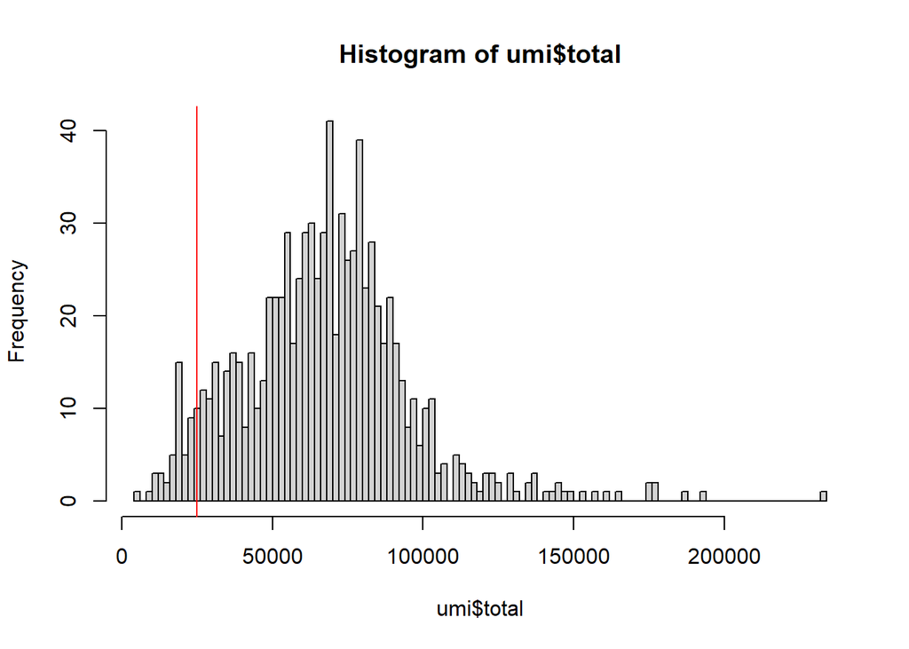

```r
#Plots a histogram showing how many cells have different library sizes (total reads per cell).
hist(
    umi$total,
    breaks = 100
)
abline(v = 25000, col = "red") #  marks 25,000 as a possible cutoff.
```

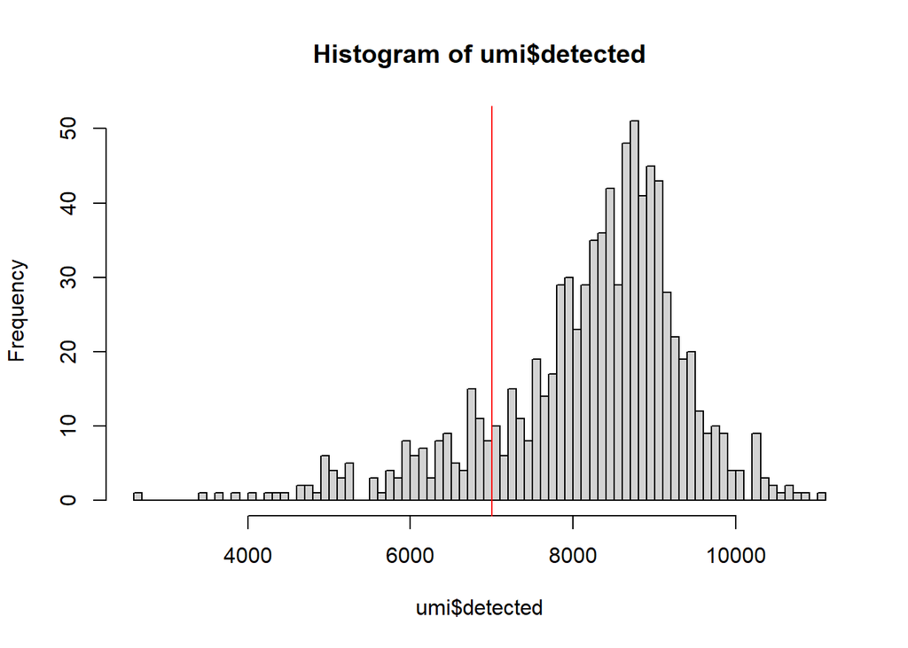

```r
#Plots the number of genes detected per cell.
hist(
    umi$detected,
    breaks = 100
)
abline(v = 7000, col = "red") #The red line marks 7,000 as a suggested minimum threshold.
```

```r
#cells that fall far to the left (very low total reads or very few detected genes). These are often: Empty droplets (not real cells; Dead or dying cells ;Technical artifacts.
```

#### 2.2. Automatic filtering

Sometimes it’s hard to come up with an obvious filtering cutoff. In this case, adaptive threshold can help us identify points that are more than 3 median absolute deviations (MADs) away from the median in any of the variables we use for QC. Be careful to specify if the correct direction of the deviation: indeed, low number of detected genes, but high MT gene percentage, are hallmarks of a low quality cell:

```r
#Flags cells with low total counts (library size).
qc.lib2 <- isOutlier(umi_cell$sum, log=TRUE, type="lower")
attr(qc.lib2, "thresholds") #  shows the actual cutoffs it used for selecting Outliers
```

```
##    lower   higher
## 23453.69      Inf
```

```r
#Flags cells with low number of detected genes.
qc.nexprs2 <- isOutlier(umi_cell$detected, log=TRUE, type="lower")
attr(qc.nexprs2, "thresholds")
```

```
##    lower   higher
## 6242.268      Inf
```

```r
#Flags cells with too much ERCC expression — which often means technical noise.
qc.spike2 <- isOutlier(umi_cell$altexps_ERCC_percent, type="higher")
attr(qc.spike2, "thresholds")
```

```
##    lower   higher
##     -Inf 3.635399
```

```r
#Flags cells with too much mitochondrial RNA, a sign of dying or stressed cells.
qc.mito2 <- isOutlier(umi_cell$subsets_Mito_percent, type="higher")
attr(qc.mito2, "thresholds")
```

```
##    lower   higher
##     -Inf 9.343529
```

```r
#Discard a cell if it failed any of the QC checks.
discard2 <- qc.lib2 | qc.nexprs2 | qc.spike2 | qc.mito2

#how many cells were flagged by each rule and in total.
DataFrame(LibSize=sum(qc.lib2), NExprs=sum(qc.nexprs2), SpikeProp=sum(qc.spike2), MitoProp=sum(qc.mito2), Total=sum(discard2))
```

```
## DataFrame with 1 row and 5 columns
##     LibSize    NExprs SpikeProp  MitoProp     Total
##   <integer> <integer> <integer> <integer> <integer>
## 1        47        65       139        75       194
```

```r
#All the actions performed above could be done in one scater command, quickPerCellQC:
#This function automatically flags bad cells using all the same logic as above and tells you why each cell was marked for removal.
reasons <- quickPerCellQC(umi_cell, sub.fields=c("subsets_Mito_percent", "altexps_ERCC_percent"))
colSums(as.matrix(reasons))
```

```
##              low_lib_size            low_n_features high_subsets_Mito_percent
##                        47                        65                        75
## high_altexps_ERCC_percent                   discard
##                       139                       194
```

```r
#metadata column that would keep the information about whether a cell is discarded or not:
umi$discard <- reasons$discard
```

#### 2.3. Visualizing the cells that are of low quality based on combined percell metrices

Quality control scatterplots help visualize how different QC metrics relate to each other, with a special focus on detecting low-quality cells (often marked by “discard” == TRUE).

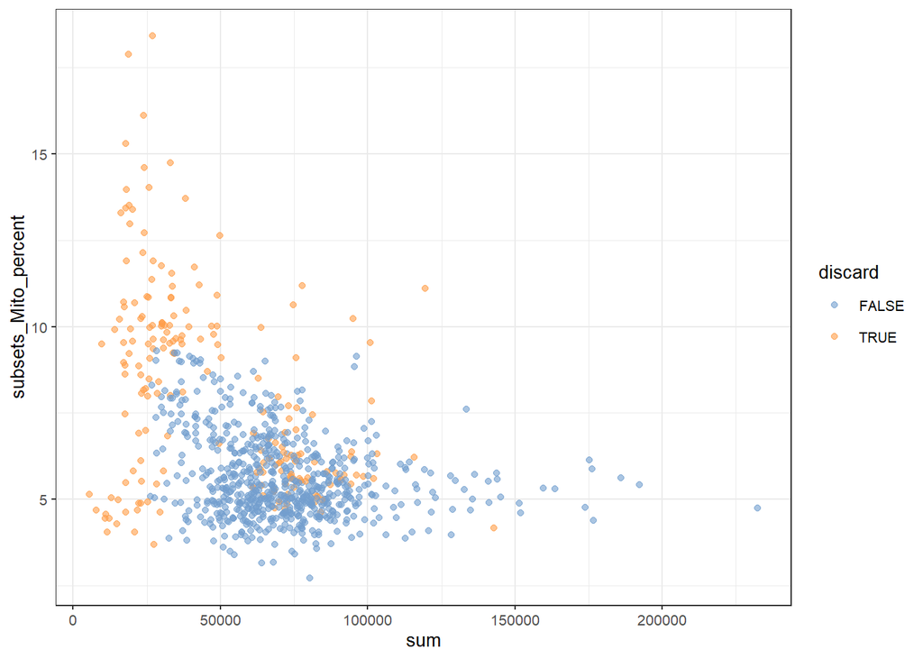

```r
# A plot of total number of counts (UMIs) per cell vs % of reads that are mitochondrial (indicative of cell stress or damage), and the discarded cells are colored. Cells with low total counts and high mitochondrial content are often stressed or dying, found in the upper-left corner.
plotColData(umi, x="sum", y="subsets_Mito_percent", colour_by="discard")
```

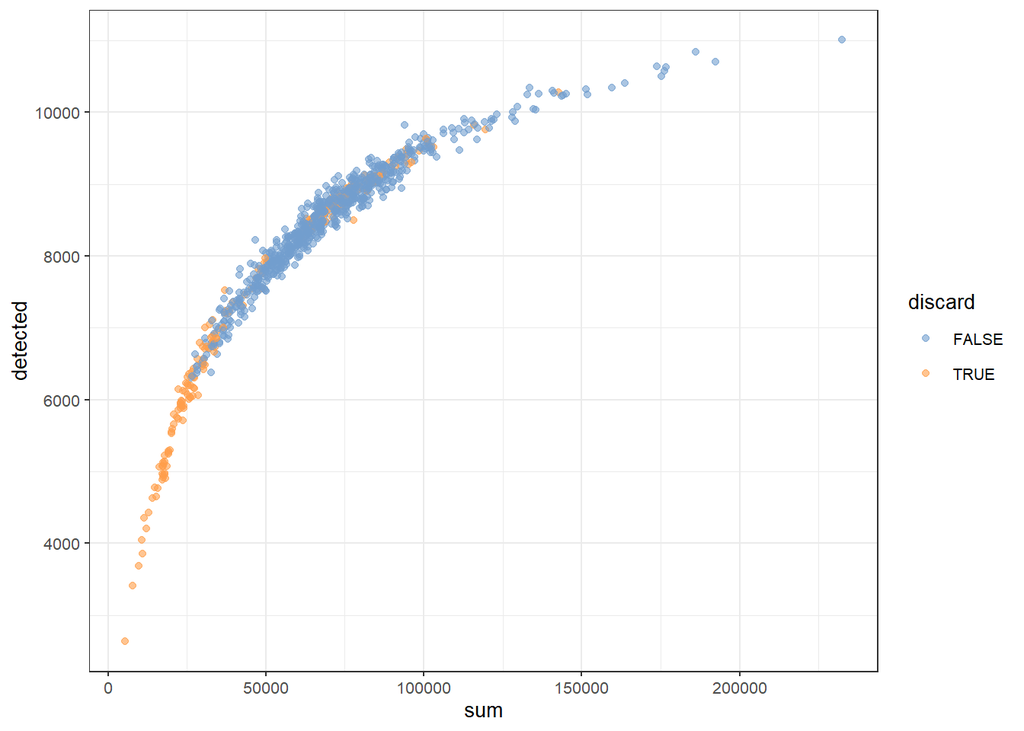

```r
#A plot of total UMI counts per cell vs number of detected genes (features), with discarded cells flagged(colored). There should be a positive correlation: more counts → more genes. Hence, cells below the main trendline (low gene detection for their count level) may be problematic. Any horizontal or vertical bands may indicate technical artifacts.
plotColData(umi, x="sum", y="detected", colour_by="discard")
```

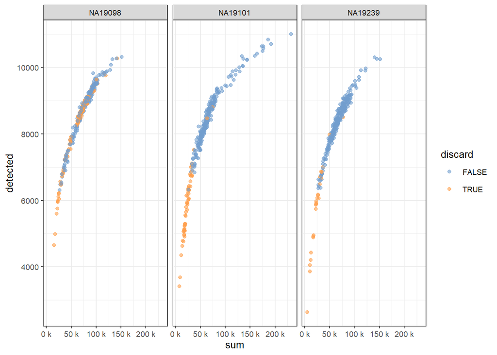

```r
#We can further split this graph by individual donor/sample, to identify sample-specific QC issues (like one individual might have globally lower counts or higher dropout).
plotColData(umi, x="sum", y="detected", colour_by="discard", other_fields = "individual") +
  facet_wrap(~individual) +
  scale_x_continuous(labels = unit_format(unit = "k", scale = 1e-3))
```

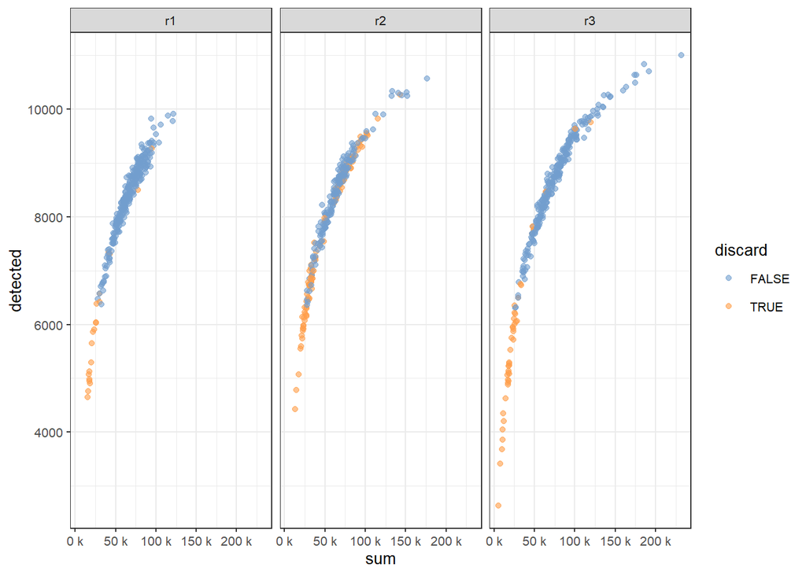

```r
##We can also split this graph by technical replicates, to assess batch effects or inconsistent library prep.We can check for replicates with lower counts or poor gene detection, increased number of discarded cells in one replicate may need investigation.
plotColData(umi, x="sum", y="detected", colour_by="discard", other_fields = "replicate") +
  facet_wrap(~replicate) +
  scale_x_continuous(labels = unit_format(unit = "k", scale = 1e-3))
```

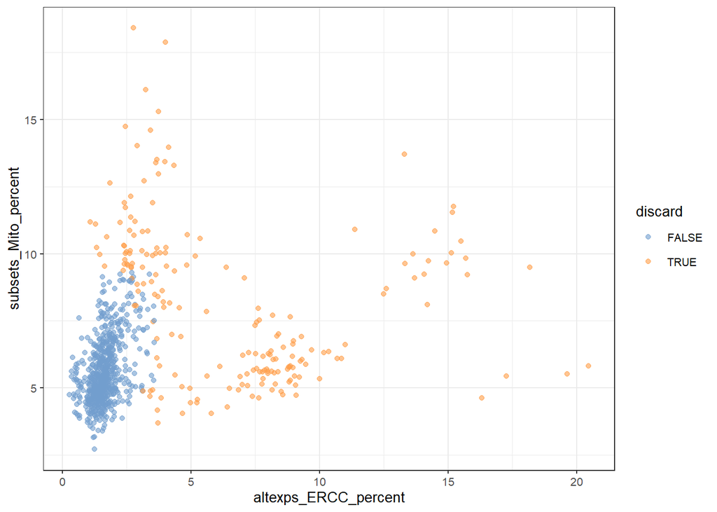

```r
# A plot of % of reads from ERCC spike-ins (external RNA controls) vs % mitochondrial reads, with discarded cells flagged(colored). High ERCC percentages can indicate low endogenous RNA content, suggesting poor quality. Hence, high mito percentages + high ERCC = very poor quality cells.Clusters of points with high values in both axes, found in the upper right quadrant are expected.
plotColData(umi, x="altexps_ERCC_percent", y="subsets_Mito_percent", colour_by="discard")
```